# Geoinformática - Práctica 7

## Patrones de Puntos

Los Puntos son entidades espaciales que pueden ser entendidas de dos formas fundamentamentales diferentes. Por un lado, los puntos pueden ser vistos como objetos fijos en el espacio, esto es, su ubicación se encuentra dada (*exógena*); desde esta perspectiva, el análisis de los puntos es muy similar al de otros tipos de datos espaciales, como son polígonos y líneas. Por otra parte, los puntos pueden ser vistos como la ocurrrencia de un evento que en teoría pudiese ocurrir en donde sea, pero únicamente se manifiesta en ciertos lugares; ésta es la aproximación que se utilizará para el resto de la práctica.

Cuando los puntos son vistos como eventos que pueden ocurrir en múltiples ubicaciones, pero únicamente suceden en unas cuantas, se tiene que una colección de dichos eventos se llama un *Patrón de Puntos*; en este caso, la ubicación de los puntos es uno de los aspectos claves del análisis. Un buen ejemplo de un Patrón de Puntos son los crímenes en una ciudad; en teoría, podrían ocurrir en muchos lugares, pero normalmente se observa que únicamente suceden en algunos de ellos. Los Patrones de Puntos se consideran *Marcados* si más atributos además de la ubicación son proporcionados, o *No Marcados* si únicamente se conocen las coordenadas del evento. Continuando con el ejemplo de los crímenes, an Patrón No Marcado resultaría de únicamente utilizar el lugar en donde ocurren éstos para el análisis, mientras que se tendría un Patrón Marcado si otros atributos, como el tipo de crimen, la extensión del daño, entre otros, también se tuviesen a la mano.

Como tal, el *Análisis de Patrones de Puntos* se enfoca en la descripción, caracterización estadística y modelación de Patrones de Puntos, centrándose específicamente en la generación de procesos que explique el comportamiento de los datos, a través de preguntas como *¿Cuál es la naturaleza de la distribución de los puntos?*, *¿Hay alguna característica en la forma en que las ubicaciones se acomodan en el espacio que pueda discernirse estadísticamente?*, *¿Por qué esos eventos ocurren en esos lugares y no en otros?*

Esta práctica pretende ser un primer acercamiento a trabajar con Patrones de Puntos en Python; como tal, se estudiará el como importar, procesar y transformar datos puntuales, así como múltiples formas en que pueden visualizarse los Patrones de Puntos.

```python
# Importación de Librerías
%matplotlib inline

import numpy as np
import pandas as pd
import geopandas as gpd
import pysal as ps
import seaborn as sns
import matplotlib.pyplot as plt
from sklearn.cluster import dbscan      # Instalada bajo el nombre 'scikit-learn'
from ipywidgets import interact, fixed
```

## Datos

Para iniciar con el Análisis de Patrones Puntuales, se trabajará con todos los robos reportados a la Procuraduría General de Justicia de la CDMX durante el 2018, así como las AGEB's de la misma con las que ya se ha trabajado en prácticas anteriores. Como es usual, es necesario definir la ubicación de estos archivos:

```python
f = 'data/'
```

Dado que los datos se encuentran almacenados como `ShapeFile`, su método de importación es el usual:

```python
%%time

# Importar los Datos
robos = gpd.read_file(f + 'robos_cdmx_2018.shp')

# Analizar rápidamente los datos
robos.info()
```

```
<class 'geopandas.geodataframe.GeoDataFrame'>
RangeIndex: 95000 entries, 0 to 94999
Data columns (total 6 columns):
id_delito    95000 non-null int64
mes          95000 non-null object
fecha        95000 non-null object
alcaldia     95000 non-null object
delito       95000 non-null object
geometry     95000 non-null object
dtypes: int64(1), object(5)
memory usage: 4.3+ MB
CPU times: user 2.57 s, sys: 120 ms, total: 2.69 s
Wall time: 2.69 s
```

Puede notarse que se ha añadido el comando `%%time` en la parte superior de la celda; esto es pues, una vez ejecutados los comandos, permite ver una medida exacta del tiempo que le tomó a la computadora el procesar el código. Se ha añadido esto pues, como puede observarse en la descripción de las columnas, se trata de una tabla bastante extensa, con 95,000 registros.

Dependidendo del tiempo de ejecución, es recomendable no utilizar los datos en su totalidad, sino únicamente una muestra aleatoria de éstos (la cual retiene las mismas propiedades). Si le tomó a la computadora más de 20s el importar el archivo (indicado por la palabra `total` al final del resultado), entonces es recomendable obtener la muestra aleatoria, de modo que el análisis y el resto de la práctica sean más sencillas de llevar.

### Muestra Aleatoria de Datos

Una vez importados los datos, obtener una muestra aleatoria es relativamente simple. Primero se ejecutará la operación completa, para analizar a detalle cada uno de los pasos:

```python
robos = gpd.read_file(f + 'robos_cdmx_2018.shp')

# Establecer un "Estado de Semilla" de modo que siempre se obtengan los mismos números aleatorios
np.random.seed(5432)

# Crear una secuencia con el mismo número de filas que las de la tabla original
ri = np.arange(len(robos))

# Reorganizar aleatoriamente los valores
np.random.shuffle(ri)

# Redefinir los índices de la tabla utilizando únicamente los primeros 10,000 valores
# de la secuencia, la cual se encuentra aleatoriamente reorganizada.
robos = robos.iloc[ri[:10000], :]

# Analizar el resultado
robos.info()
```

```
<class 'geopandas.geodataframe.GeoDataFrame'>
Int64Index: 10000 entries, 9801 to 14042
Data columns (total 6 columns):
id_delito    10000 non-null int64
mes          10000 non-null object
fecha        10000 non-null object
alcaldia     10000 non-null object
delito       10000 non-null object
geometry     10000 non-null object
dtypes: int64(1), object(5)
memory usage: 546.9+ KB
```

Analizando cada uno de los pasos a detalle:

- Primero, se creapor separado una secuencia de números iniciando desde el cero (Python siempre inicia sus cuentas desde cero, no uno) tan largo como el número de filas en la tabla de la cual se pretende tomar la muestra. Como tal, la lista inicia en 0 y continua como 1, 2, 3, 4, 5, ..., $N-1$ (siendo $N$ la longitud de la tabla, esto es, 95,000).
- Después, en la línea 10, la lista es reacomodada al azar. Después de esto, la longitud aún se mantiene de 95,000, pero el orden de los números ha sido cambiado a uno completamente aleatorio.
- Finalmente, es posible obtener la muestra, lo cual se hace en la Línea 14. Este comando se compone de dos elementos: el primero (`ri[10000]`), en el que se conservan únicamente los primeros 10,000 elementos de la lista guardada aleatoriamente (si se quiere cambiar el tamaño de la muestra, éste es el número que debe de ser cambiado); segundo (`robos.iloc`), que es una de las funciones de búsqueda utilizadas hasta ahora de la librería `Pandas`.

El truco reside en que, al consultad la tabla con el subconjunto de 10,000 números obtenidos de la reorganización aleatoria, únicamente se conservan las filas que poseen un índice entre esos números. Esto permite dos cosas: l aprimera, que únicamente se obtengan 10,000 observaciones en lugar de las 95,000 originales; segundo, que la muestra que conserva sea completamente aleatoria, debido a que la serie utilizada para su obtención también lo es.

## Visualización de Patrones de Puntos

El resto de la práctica se enfocará en aprender diferentes formas de visualizar Patrones de Puntos. En particular, se considerarán dos estrategias principales: una depende de la agregación de puntos en polígonos, mientras que la otra se basa en crear superficies contínuas utilizando Estimaciones de Densidad de Kernel (KDE).

### De Puntos a Polígonos

Dado que en prácticas anteriores se ha aprendido sobre la visualización de datos poligonales, la forma más sencilla de visualizar Patrones de Puntos es "convirtiéndolos" en polígonos y aplicándoles técnicas, como Mapeo de Coropletas (Choropleths), para visualizar su distribución espacial. Para hacer eso, se colocará una capa de Polígonos encima de un Patrón Puntual, se unirán estos dos al asignar a cada punto el polígono al que corresponden, y se crearán Coropletas a partir de las cuentas por polígono.

Esta aproximación, aunque bastante intuitiva, también genera la pregunta *¿Qué polígonos deben de utilizarse para agregar los puntos?* Idealmente, se buscarían unos límites que empaten de la forma más exacta posible con el proceso que generó a los puntos, y divida al espacio en áreas con una intensidad similar de puntos; sin embargo, esto normalmente no es posible, principalmente dado el hecho de que una de las razones por la cual se busca visualizar Patrones Puntuales es aprender a cómo generar dicho proceso, de modo que no es posible conocer *a priori* los polígonos que le corresopnden.

Si no se tiene el conjunto de polígonos ideal desde un inicio, pueden adoprtarse dos aproximaciones más realistas: Utilixzar áreas irregulares preexistentes, o crear un conjunto artificial de polígonos regulares.

#### Polígonos Irregulares Preexistentes

Para ejemplificar esta aproximación, se utilizarán las AGEB's de la Ciudad de México utilizadas en prácticas anteriores. Así que, antes que cualquier otro paso, deben de importarse éstos:

```python
# Importar y establecer índice en un sólo paso.
agebs = gpd.read_file(f + 'agebs_cdmx.shp').set_index('cvegeo')
```

El siguiente paso requiere asignar cada robo a la AGEB en donde ocurrió. Esto puede ser logrado a través de una operación de SIG común llamada *Point-In-Polygon*; a través de QGIS, esto puede ser conseguido fácilmente colocando ambas capas en un mismo proyecto y utilizando la herramienta correspondiente en el menú de *Vector* (`Vectos` -> `Data Management Tools` -> `Join Attributes by Location`). Otra forma, más rápida y eficiente, es a través de la función *Spatial Join* (`.sjoin()`) de la librería `GeoPandas`; la forma de ejecutarlo es la siguiente:

```python
# Realizar el Spatial Join
robos = gpd.sjoin(robos, agebs, op = 'intersects')

# Revisar el resultado
robos.head()
```

|  | id_delito | mes | fecha | alcaldia | delito | geometry | index_right |
| --- | --- | --- | --- | --- | --- | --- | --- |
| 9801 | 218699 | Diciembre | 2018-12-02 00:36:06 | COYOACAN | ROBO A NEGOCIO CON VIOLENCIA | POINT (2800102.53487166 816192.0862007176) | 0900300011410 |
| 92664 | 581526 | Noviembre | 2018-11-13 11:06:22 | COYOACAN | ROBO DE OBJETOS | POINT (2799737.127421565 815423.3199245736) | 0900300011410 |
| 88739 | 572797 | Agosto | 2018-08-02 01:06:24 | COYOACAN | ROBO A TRANSEUNTE DE CELULAR SIN VIOLENCIA | POINT (2799623.487643932 815450.2188560473) | 0900300011410 |
| 77333 | 547913 | Diciembre | 2018-12-19 19:37:26 | COYOACAN | ROBO A NEGOCIO SIN VIOLENCIA | POINT (2799593.235082056 815552.8011543391) | 0900300011410 |
| 59552 | 507168 | Septiembre | 2018-09-01 04:47:46 | VENUSTIANO CARRANZA | ROBO A TRANSEUNTE EN VIA PUBLICA SIN VIOLENCIA | POINT (2805598.448614738 829687.2516556303) | 0901700010475 |

Podrá observarse que el `GeoDataFrame` contenido en `robos` ahora posee una nueva columna llamada `index_right`, que corresponde a la Clave Geográfica del AGEB en donde se ocurrió el robo. La lógica detrás de esta operación reside en que `.sjoin()` realiza la unión de atributos a través de sus propiedades espaciales, y que se encuentra dictada por el argumento `op`; en este caso, debido a que se seleccionó `intersects`, a todos los robos que intersecten con un AGEB dado se les asignará la Clave Geográfica del mismo; es importante notar que el orden en que las tablas son colocadas dentro de la función es importante, pues éste dictará qué tabla será a la que se le asignarán los atributos espaciales.

Como tal, lo único que hace falta es renombrar la nueva columna para saber en futuros procesos qué es la información contenida en ella, lo cual puede lograrse a través de la función `.rename()`:

```python
# Renombrar la columna de interés
robos = robos.rename(columns = {'index_right':'ageb_urbana_cvegeo'})

# Visualizar el resultado
robos.head()
```

|  | id_delito | mes | fecha | alcaldia | delito | geometry | ageb_urbana_cvegeo |
| --- | --- | --- | --- | --- | --- | --- | --- |
| 9801 | 218699 | Diciembre | 2018-12-02 00:36:06 | COYOACAN | ROBO A NEGOCIO CON VIOLENCIA | POINT (2800102.53487166 816192.0862007176) | 0900300011410 |
| 92664 | 581526 | Noviembre | 2018-11-13 11:06:22 | COYOACAN | ROBO DE OBJETOS | POINT (2799737.127421565 815423.3199245736) | 0900300011410 |
| 88739 | 572797 | Agosto | 2018-08-02 01:06:24 | COYOACAN | ROBO A TRANSEUNTE DE CELULAR SIN VIOLENCIA | POINT (2799623.487643932 815450.2188560473) | 0900300011410 |
| 77333 | 547913 | Diciembre | 2018-12-19 19:37:26 | COYOACAN | ROBO A NEGOCIO SIN VIOLENCIA | POINT (2799593.235082056 815552.8011543391) | 0900300011410 |
| 59552 | 507168 | Septiembre | 2018-09-01 04:47:46 | VENUSTIANO CARRANZA | ROBO A TRANSEUNTE EN VIA PUBLICA SIN VIOLENCIA | POINT (2805598.448614738 829687.2516556303) | 0901700010475 |

Una vez registrada la Clave Geográfica del AGEB a la que pertenece cada robo, obtener la cuenta del número de robos por polígono es más sencillo. Nuevamente, se depende de la función `.groupby()` que toma todos los robos de la tabla y los agrupa por la Clave Geográfica; una vez agrupados, se aplica el método `.size()`, que cuenta los elementos de cad agrupo y regresa una columna indexada por las Claves Geográficas con todas las cuentas como sus valores. Para facilitar la generación de mapas, se asignan las cuentas a una nueva columna en la tabla original de `agebs`:

```python
# Crear las cuentas
robos_agebs = robos.groupby('ageb_urbana_cvegeo').size()

# Asignar las cuentas como una nueva columna de la tabla de AGEB's
agebs['no_robos'] = robos_agebs
```

El código de arriba ha creado una nueva columna en la tabla de `agebs` que contiene el número de robos que han ocurrido dentro de cada polígono. Revisando rápidamente la tabla:

```python
agebs.info()
```

```
<class 'geopandas.geodataframe.GeoDataFrame'>
Index: 2432 entries, 0900700013628 to 0901700011524
Data columns (total 2 columns):
geometry    2432 non-null object
no_robos    1992 non-null float64
dtypes: float64(1), object(1)
memory usage: 57.0+ KB
```

Para resolver este problema, primero deben de identificarse las AGEB's en las que no ocurrió ningun robo, esto es, sin un valor en la columna `no_robos`, utilizando el operador `.isnull()`:

```python
sin_robos = agebs.loc[agebs['no_robos'].isnull() , :]
sin_robos.head()
```

| cvegeo | geometry | no_robos |
| --- | --- | --- |
| 0900700013628 | POLYGON ((2810132.37214097 824698.1724370995, ... | NaN |
| 0900300011533 | POLYGON ((2795524.841431273 815177.9727343395,... | NaN |
| 0901500010235 | POLYGON ((2798881.63439129 831643.241105702, 2... | NaN |
| 0900700015802 | POLYGON ((2808463.751870028 822718.0810224824,... | NaN |
| 0900700015817 | POLYGON ((2808542.302953529 822687.5516058579,... | NaN |

También es posible verificar que en la tabla de `robos` que no existe ningún registro ocurriendo en alguna de estas AGEB's:

```python
# El método '.index' obtiene todas las Claves Geográficas de 'sin_robos', y '[0]' selecciona la primera
robos.loc[robos['ageb_urbana_cvegeo'] == sin_robos.index[0] , :]
```

|  | id_delito | mes | fecha | alcaldia | delito | geometry | ageb_urbana_cvegeo |
| --- | --- | --- | --- | --- | --- | --- | --- |

Puede observarse que, la búsqueda de todos los robos en la que su columna `ageb_urbana_cvegeo` sea igual a uno de los índices de la tabla `sin_robos` regresa una tabla vacía.

En el contexto de esta práctica, un área sin alguna ocurrencia del evento podría derivarse directamente en un cero para la cuenta total; sin embargo, en otros casos, esta no es necesariamente la respuesta correcta, razón pr la cual `pandas` decide dejar un *Valor Nulo* (`NaN`) cuando no es capaz de obtener una cuenta. Para corregir este detalle, existe una función llamada `.fillna()`, que buscará todos los Valores Nulos de una tabla y los reemplzará con el valor que se le indique que, en este caso, es 0:

```python
agebs = agebs.fillna(0)
```

Como tal, si se revisa nuevamente la tabla de `agebs`, ya no se encontrarán valores nulos:

```python
agebs.info()
```

```
<class 'geopandas.geodataframe.GeoDataFrame'>
Index: 2432 entries, 0900700013628 to 0901700011524
Data columns (total 2 columns):
geometry    2432 non-null object
no_robos    2432 non-null float64
dtypes: float64(1), object(1)
memory usage: 137.0+ KB
```

Dado lo anterior, es posible generar un mapa con las cuentas. Desde el punto de vista técnico, se trata de un Mapa de Coropletas, tal y como se realizó en la Práctica 4:

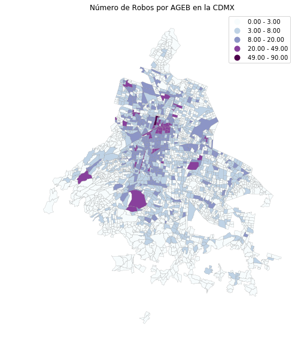

```python
# Preparar la figura y sus filas
fig, filas = plt.subplots(1 , figsize = (10,10))

# Graficar una Coropleta dividia con Fisher-Jenks, con su leyenda
agebs.plot(column = 'no_robos' , scheme = 'fisher_jenks' , legend = True , ax = filas , cmap = 'BuPu' , edgecolor = 'grey', linewidth = 0.2)

# Eliminar los ejes
filas.set_axis_off()

# Asignar un título
filas.set_title('Número de Robos por AGEB en la CDMX')

# Mostrar el Resultado
plt.show()
```

El mapa anterior muestra una concentración de robos principalmente en la Alcaldía Cuauhtémoc de la Ciudad de México; sin embargo, también muestra una alta concentración en las AGEB's que tienen un mayor tamaño, detalle que lleva a una importante reflexión. Como se mencionó anteriormente, los *robos* son un evento que, en teoría, pueden ocurrir en cualquier parte de la ciudad y, debido a esta naturaleza, el tamaño de una AGEB puede influir en le hecho que dentro de ésta ocurra el crimen o no; mientras más grande sea un AGEB, más problable es que un robo ocurra en su interior. Como tal, si no se consideran factores como éste dentro del mapa, se puede caer en el error de simplemente estar mapeando la incidencia de robos sin realizar un análisis detallado.

Para obtener un mapeado más exacto, lo que se desaearía observar el la *intensidad* de los robos, no las cuentas brutas de éstos. Para hacer esto, pueden recurrirse a indicadores como el Número de Robos por cada 1,000 habitantes; en este caso, se determinará el Número de Robos por km² dentro del AGEB.

Para hacer esto, puede recurrirse a la propiedad `.area` de la tabla `agebs`, la cual es posible obtener gracias a la librería de `GeoPandas`:

```python
agebs.area.head()
```

```
cvegeo
0900700013628     37139.644596
0900300011533     91021.367703
0901500010235     30952.251603
0900200010097    177197.822865
0900200011184     48372.993755
dtype: float64
```

Es importante notar que el área calculada por `GeoPandas` depende directamente de la proyección en la que se encuentran los datos; si se observa la propiedad `.crs` de la tabla:

```python
agebs.crs
```

```
{'init': 'epsg:6362'}
```

Puede observarse que ésta se encuentra en la proyección EPSG: 6362, que equivale a la [Cónica Conforme de Lambert (LCC) para México](https://epsg.io/6362); ésta proyección utiliza unidades en metros y, como tal, el área calculada es medida en metros cuadrados (m²). Para convertir esta área en km², únicamente es necesario realizar la conversión correspondiente, para entonces poder añadir este valor como una nueva columna en la tabla original:

```python
# Cálculo de Área y creación de nueva columna
agebs['area'] = agebs.area / 1000000

# Visualización de resultados
agebs.head()
```

| cvegeo | geometry | no_robos | area |
| --- | --- | --- | --- |
| 0900700013628 | POLYGON ((2810132.37214097 824698.1724370995, ... | 0.0 | 0.037140 |
| 0900300011533 | POLYGON ((2795524.841431273 815177.9727343395,... | 0.0 | 0.091021 |
| 0901500010235 | POLYGON ((2798881.63439129 831643.241105702, 2... | 0.0 | 0.030952 |
| 0900200010097 | POLYGON ((2792415.238538118 836846.39013781, 2... | 5.0 | 0.177198 |
| 0900200011184 | POLYGON ((2792260.139078679 836768.777211847, ... | 2.0 | 0.048373 |

A partir de esto, es sencillo obtener la tasa de robos por unidad de área en cada AGEB, esto es, un indicador de intensidad:

```python
# Cálculo de Robos por km2
agebs['robos_int'] = agebs['no_robos'] / agebs['area']

# Visualización de Resultados
agebs.head()
```

| cvegeo | geometry | no_robos | area | robos_int |
| --- | --- | --- | --- | --- |
| 0900700013628 | POLYGON ((2810132.37214097 824698.1724370995, ... | 0.0 | 0.037140 | 0.000000 |
| 0900300011533 | POLYGON ((2795524.841431273 815177.9727343395,... | 0.0 | 0.091021 | 0.000000 |
| 0901500010235 | POLYGON ((2798881.63439129 831643.241105702, 2... | 0.0 | 0.030952 | 0.000000 |
| 0900200010097 | POLYGON ((2792415.238538118 836846.39013781, 2... | 5.0 | 0.177198 | 28.217051 |
| 0900200011184 | POLYGON ((2792260.139078679 836768.777211847, ... | 2.0 | 0.048373 | 41.345384 |

Dada la intensidad, es posible crear un nuevo Mapa de Coropletas, esta vez utilizando la columna `robos_int` como medida para la clasificación:

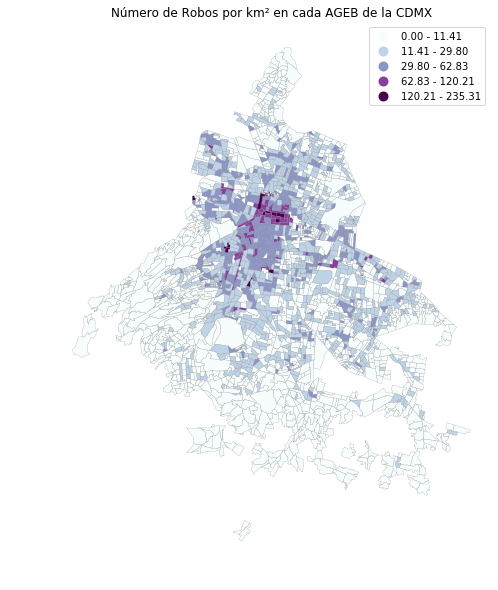

```python
# Preparar la figura y sus filas
fig, filas = plt.subplots(1 , figsize = (10,10))

# Graficar una Coropleta dividia con Fisher-Jenks, con su leyenda
agebs.plot(column = 'robos_int' , scheme = 'fisher_jenks' , legend = True , ax = filas , cmap = 'BuPu' , edgecolor = 'grey', linewidth = 0.2)

# Eliminar los ejes
filas.set_axis_off()

# Asignar un título
filas.set_title('Número de Robos por km² en cada AGEB de la CDMX')

# Mostrar el Resultado
plt.show()
```

Dado este ajuste, es posible observar que las AGEB's más grandes ya no necesariamente son las de mayor intensidad, pues el indicador permite deducir que su tamaño es tan grande que el hecho de que un robo haya ocurrido en su interior puede derivarse meramente a este detalle. Por otra parte, las AGEB's en la Alcaldía Cuahtémoc continúan con una coloración intensa, mostrando que, aún siendo pequeñas, el número de robos que han ocurrido en su interior puede derivarse de factores más allá de su tamaño.

#### Polígonos Regulares - Hex-Binning

En algunos casos, se tiene que los polígonos con los que se cuenta no son lo suficientemente adecuados para agregar los puntos en ellos, o simplemente no se cuenta con ningún tipo de área de agregación; bajo estas circunstancias, una alternativa válida es crear una topología artificial de polígonos que puedan ser utilizados para agregar los puntos. Existen múltiples formas de hacer esto, pero la más común es crear una Red de Hexágonos; ésta proporciona una topología regular, pues cada polígono es de la misma forma y tamaño, que resulta mejor que los círculo, pues cubre todo el espacio sin sobreponer figuras, y posee más vértices que los cuadrados, resolviendo problemas relacionados a éstos.

A través de Python existe una forma simplificada de crear esta capa de hexágonos y agregar los puntos en ellos a través de una sola línea, gracias a la [función `.hexbin()` de la librería `matplotlib`](https://matplotlib.org/3.1.0/api/_as_gen/matplotlib.pyplot.hexbin.html). Éstos son los comandos para crear la Capa Hexagonal:

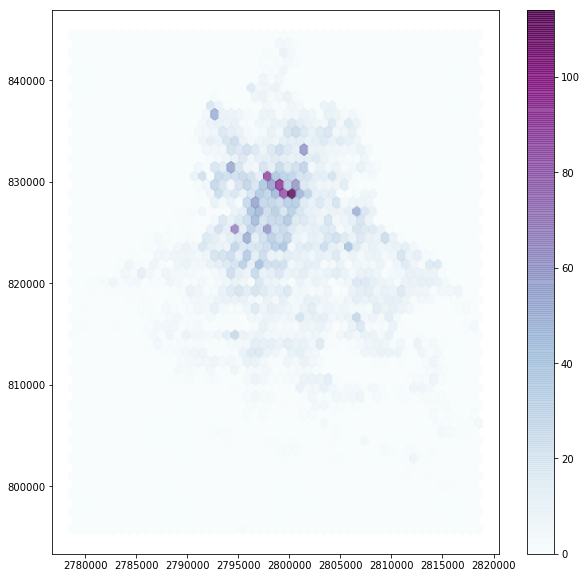

```python
# Preparación de la Figura y sus Filas
fig , filas = plt.subplots(1 , figsize = (10,10))

# Añadir capa de hexágonos que muestra la cuenta de puntos en cada polígono
hb = filas.hexbin(robos['geometry'].x , robos['geometry'].y, gridsize = 50, alpha = 0.8, cmap = 'BuPu')

# Añadir Barra de Color de referencia (Opcional)
plt.colorbar(hb)
```

Puede notarse que lo único que se necesita es llamar directamente a la función `.hexbin()` sobre las filas (`filas`) de la figura que se está creando, añadir las coordenadas de los puntos (llamadas con `robos['geometry'].x` y `robos['geometry'].y`); los argumentos adicionales manejan el número de hexágonos por cada eje (`gridsize`, teniendo 50 para una capa de 50x50 polígonos), la transparencia deseada (`alpha`) y los colores a utilizar en el mapa (`cmap`). Adicionalmente, se incluye una Barra de Colores para entender el significado de los colores; debe notarse que se realiza colocando el objeto en el que se ha almacenado el resultado de `hexbin`, siendo en este caso la variable `hb`.

Teniendo la base, es posible seguir la rutina de Generación de Mapas utilizada hasta ahora para generar un mapa completo del número de robos en la Ciudad de México:

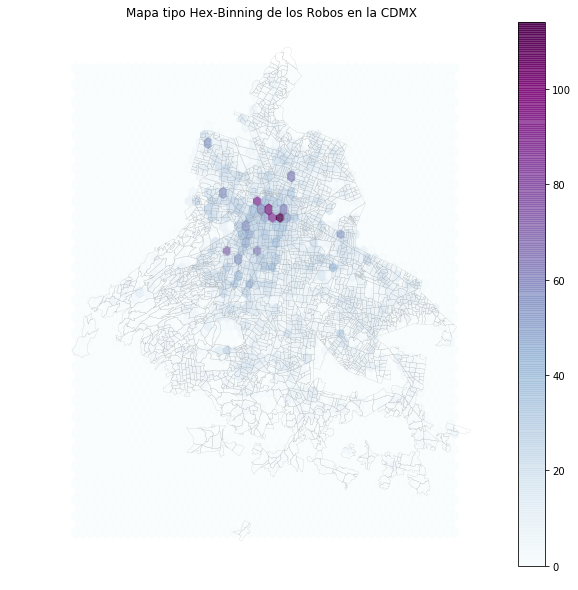

```python
# Preparación de la figura y sus filas
fig , filas = plt.subplots(1, figsize = (10,10))

# Añadir capa de hexágonos que muestra la cuenta de puntos en cada polígono
hb = filas.hexbin(robos['geometry'].x , robos['geometry'].y, gridsize = 50, alpha = 0.8, cmap = 'BuPu')

# Añadir Barra de Color de referencia (Opcional)
plt.colorbar(hb)

# Añadir una Capa Base con las AGEB's
agebs.plot(ax = filas, facecolor = '', linewidth = 0.2, edgecolor = 'grey', alpha = 0.5)

# Remover los ejes
filas.set_axis_off()

# Añadir título al mapa
filas.set_title('Mapa tipo Hex-Binning de los Robos en la CDMX')

# Mostrar el resultado
plt.show()
```

## Estimación de Densidad de Kernel

Utilizar la técnica de 'Hexagonal-Binning' puede resultar una solución rápida cuando no se tiene una buena capa de polígonos para agregar los puntos, y alguna de sus propiedades, como la equivalencia en tamaños de cada polígono, puede ayudar a aliviar algunos de los problemas asociados a una "mala" toplogía irregular (esto es, una que no se ajusta perfectamente al proceso que generó el patrón de puntos). Sin embargo, esto aún no resuelve del todo el dilema derivado del Problema de Unidad de Área Modificable (MUAP, por sus siglas en inglés, estudiado en la Práctica 3 y en la Práctica Adicional); después de todo, aún se están imponiendo límites arbitrarios y agregando según éstos, de modo que la posibilidad de no acercarse del todo a la distribución correcta del Patrón de Puntos es bastante probable.

Una forma de resolver este problema es evitando la agregación completamente. En su lugar, puede intentarse estimar una variable *contínua*, como lo es la probabilidad observada de la distribución. El método más común utilizado para realizar esto es la Estimación de la Densidad de Kernel (KDE, por sus siglas en inglés), método que busca contar el número de puntos de forma contínua; en lugar de utilizar una cuenta discreta, en la que se incluye un punto en la cuenta si éste se encuentra dentro de los límites de un polígono, el método KDE utiliza funciones (kernel) que incluye a los punts, pero les asigna diferentes pesos dependiendo de su distancia al punto desde el cual se está realizando la cuenta.

Aunque el algoritmo para realizar esta estimación no es nada trivial, dentro de Python se trata de una tarea muy simplificada gracias a la existencia de [la función `.kdeplot()` de la librería `seaborn`](https://seaborn.pydata.org/generated/seaborn.kdeplot.html). El comando para crear un mapa de Densidad de Kernel de forma muy sencilla es:

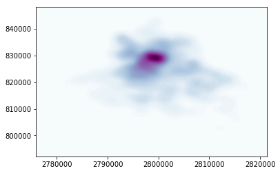

```python
sns.kdeplot(robos['geometry'].x, robos['geometry'].y, n_levels = 50, shade = True, cmap = 'BuPu')
```

La librería `seaborn` sintetiza enormemente todo el proceso en una sola línea. La función `.kdeplot()` (que también puede utilizarse para crear una Estimación de Densidad de Kernel de una sola variable) toma las coordenadas X (`robos['geometry'].x`) y Y (`robos['geometry'].y`) de los puntos como sus únicos argumentos obligatorios; adicionalmente, se especifican el número de niveles en el que se busca que se coloree el gradiente (`n_levels`), si se busca colorear el espacio entre cada uno de los niveles (`shade`) y los colores de preferencia (`cmap`).

Una vez entendido el funcionamiento básico de la herramienta, puede ser colocada dentro de un mapa más completo, siendo la diferencia más importante del proceso que debe de indicársele a `.kdeplot()` dónde debe de ser colocado (en este caso, las `filas` de la figura):

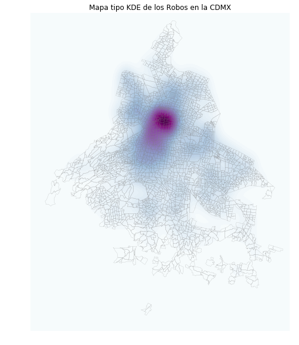

```python
# Preparación de figuras y filas
fig, filas = plt.subplots(1, figsize = (10,10))

# Generar el KDE
sns.kdeplot(robos['geometry'].x, robos['geometry'].y, n_levels = 50, shade = True, cmap = 'BuPu', ax = filas)

# Añadir una Capa Base con las AGEB's
agebs.plot(ax = filas, facecolor = '', linewidth = 0.2, edgecolor = 'grey', alpha = 0.75)

# Remover los ejes
filas.set_axis_off()

# Añadir título al mapa
filas.set_title('Mapa tipo KDE de los Robos en la CDMX')

# Mostrar el resultado
plt.show()
```

## Agregación de Puntos

En esta última sección, se aprenderá el método para identificar Agregaciones (*Clusters*) de puntos, basándose en su densidad a lo largo del espacio. Para esto, se utilizará el conocido algoritmo **DBSCAN**; en éste, se considera como *Cluster* a una concentración de por lo menos $m$ puntos, cada uno con una distancia de $r$ de por lo menos alguno de los otros puntos de la agregación. A partir de esto, los puntos del conjunto son dividos en tres categorías:

- Ruido (*Noise*) - Aquellos puntos fuera del *Cluster*.
- Núcleos (*Cores*) - Puntos dentro de una agregación que cumpla con tener por lo menos $m$ puntos dentro de una distancia de $r$.
- Fronteras (*Borders*) - Puntos dentro de una agregación con menos de $m$ puntos dentro del mismo en una distancia de $r$.

Tanto $m$ y $r$ necesitan ser especificados con anterioridad por el usuario antes de ejecutar el algoritmo **DBSCAN**; esto es un factor clave, pues el valor de estos parámetros puede influir significativamente en el resultado final. Antes de continuar explorando a detalle, resulta pertinente realizar una primera ejecución del algoritmo.